# (PSL) Logistic Regression

```python
import pandas as pd
import numpy as np

import matplotlib.pyplot as plt
import matplotlib as mpl
import seaborn as sns

import statsmodels.api as sm
from sklearn.metrics import confusion_matrix, ConfusionMatrixDisplay
```

## 1. The Convergence Issue

```python
np.random.seed(0)
n = 10
x = np.random.uniform(0,1,(n,2))
y = (x.sum(1) > 1).astype(int)
```

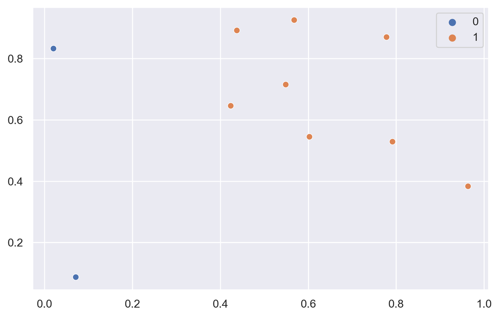

```python
mpl.rcParams['figure.dpi'] = 250
mpl.rcParams['figure.figsize'] = (8, 5)
sns.set()
sns.scatterplot(x = x[:,0], y = x[:,1], hue = y);
```

```python
x = np.hstack([x, np.ones((n,1))])
myfit = sm.GLM(y, x, family = sm.families.Binomial()).fit();
```

```python
print(myfit.summary());
```

[output not shown]

In cases where data are perfectly separable, the likelihood for the logistic model doesn't converge. The maximum likelihood estimate (MLE) of the parameter beta may tend towards either positive infinity or negative infinity.

However, despite this issue, the separating line remains well-defined, allowing us to use the fitted model for predictions. This is because the separating condition, such as $3 x_1 + x_2 > 2,$ remains consistent even if we scale the coefficients. For instance, $300 x_1 + 100 x_2 > 200$ expresses the same line.

## 2. Heart Data

Next we discuss fitting a logistic regression model and interpreting the coefficients and other outcomes. For illustration, we use the Coronary Risk‐Factor Study data, which consists of 462 males between the ages of 15 and 64 from a heart-disease high-risk region of the Western Cape, South Africa.

The response variable, `chd`, is binary (1 for disease presence and 0 for absence), and there are nine covariates, mostly numerical, except for "family history," which is binary.

- **sbp**: systolic blood pressure
- **tobacco**: cumulative tobacco (kg)
- **ldl**: low densiity lipoprotein cholesterol
- **adiposity**
- **famhist**: family history of heart disease (Present, Absent)
- **typea**: type‐A behavior
- **obesity**
- **alcohol**: current alcohol consumption
- **age**: age at onset

```python
url = "https://web.stanford.edu/~hastie/ElemStatLearn//datasets/SAheart.data"
df = pd.read_csv(url, index_col=0)
df;
```

```python
X = df.iloc[:,0:9]
y = df['chd']
X = pd.get_dummies(X, drop_first=True).astype(float)
X['(intercept)'] = 1
```

## 3. Fit a logistic model

### 3.1 Model fitting

We use the `statsmodels` package [[Link](https://www.statsmodels.org/stable/discretemod.html)], which can handle various models, including Poisson regression. However, in this lecture, we are focusing on logistic regression.

The grammar for fitting the logistic regression model is similar to that of a linear model, except that we must pass in the argument `family=sm.families.Binomial()` in order to tell `statsmodels` to run a logistic regression rather than some other type of generalized linear model.

```python
heartfull = sm.GLM(y, X, family = sm.families.Binomial()).fit()
```

### 3.2 Coefficient Interpretation

After fitting the logistic regression model, you can run a summary.

The first column of the coefficient matrix contains estimated coefficients, including the intercept and coefficients associated with each feature. The interpretation of these coefficients is similar to the regular linear model. For instance, if you increase `sbp` by one unit, you will increase the response by 0.0065.

However, in logistic regression, the response is the log-odds, $\log (p / (1 - p))$, and the interpretation of coefficients involves exponentiation. Increasing $X_1$ by one unit corresponds to the change in odds by $\exp(\beta_1)$

$$ \log \frac{p}{1-p} = \beta_0 + (X_1 + 1) \beta_1 + \cdots + X_p \beta_p = (\beta_0 + X_1 \beta_1 + \cdots + X_p \beta_p) + \beta_1 $$

- If $\beta_1$ is positive, $\exp( \beta_1) > 1,$ indicating an increase in odds.
- If $\beta_1$ is negative, $\exp( \beta_1) < 1,$, indicating a decrease in odds.

```python
print(heartfull.summary())
```

```
                 Generalized Linear Model Regression Results
==============================================================================
Dep. Variable:                    chd   No. Observations:                  462
Model:                            GLM   Df Residuals:                      452
Model Family:                Binomial   Df Model:                            9
Link Function:                  Logit   Scale:                          1.0000
Method:                          IRLS   Log-Likelihood:                -236.07
Date:                Mon, 23 Oct 2023   Deviance:                       472.14
Time:                        17:37:45   Pearson chi2:                     452.
No. Iterations:                     5   Pseudo R-squ. (CS):             0.2353
Covariance Type:            nonrobust
===================================================================================
                      coef    std err          z      P>|z|      [0.025      0.975]
-----------------------------------------------------------------------------------
sbp                 0.0065      0.006      1.135      0.256      -0.005       0.018
tobacco             0.0794      0.027      2.984      0.003       0.027       0.132
ldl                 0.1739      0.060      2.915      0.004       0.057       0.291
adiposity           0.0186      0.029      0.635      0.526      -0.039       0.076
typea               0.0396      0.012      3.214      0.001       0.015       0.064
obesity            -0.0629      0.044     -1.422      0.155      -0.150       0.024
alcohol             0.0001      0.004      0.027      0.978      -0.009       0.009
age                 0.0452      0.012      3.728      0.000       0.021       0.069
famhist_Present     0.9254      0.228      4.061      0.000       0.479       1.372
(intercept)        -6.1507      1.308     -4.701      0.000      -8.715      -3.587
===================================================================================
```

The remaining columns in the summary table provide information similar to that in linear regression. They report standard errors, z-values, and p-values. Logistic regression iteratively fits a weighted least square model. From this model, standard errors for coefficients are calculated, leading to Z-values. Using a normal distribution, we can calculate two-sided p-values to determine the significance of coefficients.

### 3.3 Correlation among variables affects coefficients

Looking at the heart disease data, most coefficients are positive, meaning an increase in those features leads to an increased likelihood of heart disease. Interestingly, the coefficient for `obesity` is negative, implying that an increase in body fat (obesity) reduces the chances of heart disease. This might seem counter-intuitive, but it's due to correlations between features.

```python
pd.get_dummies(df, drop_first=True).corr().round(2)
```

|  | sbp | tobacco | ldl | adiposity | typea | obesity | alcohol | age | chd | famhist_Present |
| --- | --- | --- | --- | --- | --- | --- | --- | --- | --- | --- |
| sbp | 1.00 | 0.21 | 0.16 | 0.36 | -0.06 | 0.24 | 0.14 | 0.39 | 0.19 | 0.09 |
| tobacco | 0.21 | 1.00 | 0.16 | 0.29 | -0.01 | 0.12 | 0.20 | 0.45 | 0.30 | 0.09 |
| ldl | 0.16 | 0.16 | 1.00 | 0.44 | 0.04 | 0.33 | -0.03 | 0.31 | 0.26 | 0.16 |
| adiposity | 0.36 | 0.29 | 0.44 | 1.00 | -0.04 | 0.72 | 0.10 | 0.63 | 0.25 | 0.18 |
| typea | -0.06 | -0.01 | 0.04 | -0.04 | 1.00 | 0.07 | 0.04 | -0.10 | 0.10 | 0.04 |
| obesity | 0.24 | 0.12 | 0.33 | 0.72 | 0.07 | 1.00 | 0.05 | 0.29 | 0.10 | 0.12 |
| alcohol | 0.14 | 0.20 | -0.03 | 0.10 | 0.04 | 0.05 | 1.00 | 0.10 | 0.06 | 0.08 |
| age | 0.39 | 0.45 | 0.31 | 0.63 | -0.10 | 0.29 | 0.10 | 1.00 | 0.37 | 0.24 |
| chd | 0.19 | 0.30 | 0.26 | 0.25 | 0.10 | 0.10 | 0.06 | 0.37 | 1.00 | 0.27 |
| famhist_Present | 0.09 | 0.09 | 0.16 | 0.18 | 0.04 | 0.12 | 0.08 | 0.24 | 0.27 | 1.00 |

### 3.4 Compute deviances

In logistic regression, we don't have residual sum of squares or $\sigma$ estimate. Instead, we focus on metrics like "deviance" (reported at the end of the summary). These metrics help assess how well the model fits the data and can be used for model comparison and evaluation.

Deviance measures model goodness of fit, based on likelihood comparisons. When all $x_i$ are unique, the deviance is defined as (-2) times the log-likelihood, as follows: $$ \text{Deviance} = -2 \cdot \Big (\sum_{i: y_i = 1} \log \hat{p}_i + \sum_{i: y_i = 0} (1-\hat{p}_i) \Big). $$ Here $\hat{p}_i$ represents the estimated probability off $P(Y = 1| X = x_i)$.

```python
def log_likelihood(phat, y):
  return -(np.log(phat[y == 1]).sum() +  np.log(1 - phat[y == 0]).sum())
```

```python
phat = heartfull.fittedvalues
print("Residual Deviance: " + str(-2*log_likelihood(phat, y)))
```

```
Residual Deviance: -472.1400323724979
```

### 3.5 Prediction

Estimation (probability of being 1) on the training samples.

```python
sns.set_theme(style="white", palette=None)
ConfusionMatrixDisplay(confusion_matrix(y, heartfull.fittedvalues > 0.5)).plot()
plt.show()
```

[output not shown]

Consider the following three males with the same value on all other predictors except age: min, max, and median. What’s the estimated chance of getting heart disease for each of them?

```python
testsamples = X.iloc[[0,0,0],:].copy()
testsamples;
testsamples.loc[:,'age'] = [X['age'].min(), X['age'].median(), X['age'].max()]
testsamples;
```

#### Predicted Log-Odds

```python
heartfull.predict(testsamples, which = 'linear')
```

```
row.names
1   -0.767328
1    0.589432
1    1.448714
dtype: float64
```

#### Predicted Probabilities

```python
heartfull.predict(testsamples, which = 'mean')
```

```
row.names
1    0.317057
1    0.643235
1    0.809800
dtype: float64
```

## 4. Variable Selection

After fitting a logistic regression model, we often encounter a situation similar to what we've experienced with linear models: there may be numerous features, but only a subset of them is truly relevant. Therefore, we need to perform variable selection.

### 4.1 Stepwise Model Selection with AIC and BIC

We can employ criteria such as AIC and BIC because the logistic regression model has a likelihood. We can perform stepwise model selection using the `stepAIC` function implemented in `Python_W3_VarSel_SubsetSelection`. Since we're performing logistic regression, we need to modify the `computeAIC` function.

```python
def computeAIC(X, Y, k=2):
    model = sm.GLM(Y, X, family = sm.families.Binomial()).fit()
    return 2*log_likelihood(model.fittedvalues, Y) + k*X.shape[1]
```

How to perform this using a stepwise approach? We start with the full model and then consider various actions, which include removing existing covariates or taking no action; then calculate the corresponding AIC for each scenario, rank them from smallest to largest, and select the action associated with the smallest AIC. For instance, we may decide to remove the `alcohol` variable in the first step.

In the next stage, we repeat this process, either removing existing covariates, taking no action, or even adding back previously removed ones. We rank these actions by their AIC values and continue removing features until we reach a point where taking no action results in the smallest AIC. At this point, we stop and consider our selected model, which typically includes a subset of the original features.

```python
def stepAIC(X, Y, features = X.columns, AIC = True):
    AIC_list, action_list, feature_list = [], [], []
    best_AIC = np.inf
    best_action = ' '

    n = len(Y)
    if AIC:
        k = 2
    else:
        k = np.log(n)
    AIC = computeAIC(X[features], Y, k)

    while(AIC < best_AIC):
        AIC_list.append(AIC)
        feature_list.append(list(features))
        action_list.append(best_action)
        best_AIC = AIC

        tmp_AIC_list, tmp_action_list, tmp_feature_list = [], [], []

        for p in features:
            tmp_features = features.drop(p)
            tmp_AIC = computeAIC(X[tmp_features], Y, k)
            tmp_AIC_list.append(tmp_AIC)
            tmp_feature_list.append(tmp_features)
            tmp_action_list.append('- ' + p)

        remaining_features = [p for p in X.columns if p not in features]
        for p in remaining_features:
            tmp_features = list(features) + [p]
            tmp_AIC = computeAIC(X[tmp_features], Y, k)
            tmp_AIC_list.append(tmp_AIC)
            tmp_feature_list.append(tmp_features)
            tmp_action_list.append('+ ' + p)

        best_model = np.array(tmp_AIC_list).argmin()
        AIC = tmp_AIC_list[best_model]
        features = tmp_feature_list[best_model]
        best_action = tmp_action_list[best_model]

    return pd.DataFrame({'AIC': AIC_list,
                         'action': action_list,
                       'features': feature_list})
```

#### AIC

```python
myout = stepAIC(X, y)
pd.options.display.max_colwidth = 100
myout
```

|  | AIC | action | features |
| --- | --- | --- | --- |
| 0 | 492.140032 |  | [sbp, tobacco, ldl, adiposity, typea, obesity, alcohol, age, famhist_Present, (intercept)] |
| 1 | 490.140769 | - alcohol | [sbp, tobacco, ldl, adiposity, typea, obesity, age, famhist_Present, (intercept)] |
| 2 | 488.548965 | - adiposity | [sbp, tobacco, ldl, typea, obesity, age, famhist_Present, (intercept)] |
| 3 | 487.979894 | - sbp | [tobacco, ldl, typea, obesity, age, famhist_Present, (intercept)] |
| 4 | 487.685578 | - obesity | [tobacco, ldl, typea, age, famhist_Present, (intercept)] |

#### BIC

You can apply a similar process using BIC. Just note that for BIC, you should set the parameter `AIC = False`, so `k` is set to be `log(n)` instead of `2`.

```python
myout = stepAIC(X, y, AIC = False)
myout
```

|  | AIC | action | features |
| --- | --- | --- | --- |
| 0 | 533.495681 |  | [sbp, tobacco, ldl, adiposity, typea, obesity, alcohol, age, famhist_Present, (intercept)] |
| 1 | 527.360853 | - alcohol | [sbp, tobacco, ldl, adiposity, typea, obesity, age, famhist_Present, (intercept)] |
| 2 | 521.633484 | - adiposity | [sbp, tobacco, ldl, typea, obesity, age, famhist_Present, (intercept)] |
| 3 | 516.928848 | - sbp | [tobacco, ldl, typea, obesity, age, famhist_Present, (intercept)] |
| 4 | 512.498967 | - obesity | [tobacco, ldl, typea, age, famhist_Present, (intercept)] |

It's worth mentioning that both AIC and BIC algorithms tend to select the same model, a model with five covariates.

```python
features = myout['features'][len(myout) - 1]
heartAIC = sm.GLM(y, X[features], family=sm.families.Binomial()).fit()
print(heartAIC.summary())
```

```
                 Generalized Linear Model Regression Results
==============================================================================
Dep. Variable:                    chd   No. Observations:                  462
Model:                            GLM   Df Residuals:                      456
Model Family:                Binomial   Df Model:                            5
Link Function:                  Logit   Scale:                          1.0000
Method:                          IRLS   Log-Likelihood:                -237.84
Date:                Thu, 03 Aug 2023   Deviance:                       475.69
Time:                        16:52:23   Pearson chi2:                     458.
No. Iterations:                     5   Pseudo R-squ. (CS):             0.2295
Covariance Type:            nonrobust
===================================================================================
                      coef    std err          z      P>|z|      [0.025      0.975]
-----------------------------------------------------------------------------------
tobacco             0.0804      0.026      3.106      0.002       0.030       0.131
ldl                 0.1620      0.055      2.947      0.003       0.054       0.270
typea               0.0371      0.012      3.051      0.002       0.013       0.061
age                 0.0505      0.010      4.944      0.000       0.030       0.070
famhist_Present     0.9082      0.226      4.023      0.000       0.466       1.351
(intercept)        -6.4464      0.921     -7.000      0.000      -8.251      -4.642
===================================================================================
```

### 4.2 Model selection with Lasso/Ridge

We can also use Lasso or Ridge, or even a combination of both. As I mentioned earlier, logistic regression is essentially a weighted least squares problem. Therefore, we can extend the existing algorithms for linear models with Lasso to logistic regression with Lasso/Ridge penalty.

#### Use glmnet

There are different versions of glmnet. For example,

- `glmnet_python` https://github.com/bbalasub1/glmnet_python/blob/master/test/example_binomial.py
- `LogitNet` from `python-glmnet` https://github.com/civisanalytics/python-glmnet

#### Use `sklearn`

Use `sklearn.linear_model.LogisticRegression` [[Link](https://scikit-learn.org/stable/modules/generated/sklearn.linear_model.LogisticRegression.html)]

## 5. Challenger O-Ring Data

The Challenger O-Ring Data is a historical dataset related to the Space Shuttle Challenger disaster, which occurred on January 28, 1986. The disaster resulted in the loss of seven crew members and the destruction of the spacecraft. It was a pivotal moment in the history of space exploration and had significant implications for engineering, safety, and decision-making processes.

On the night preceding the launch, a critical decision had to be made regarding the safety of proceeding with the launch.

One of the critical factors under consideration was the ambient temperature on the day of the launch. It was known that the O-rings were less flexible at lower temperatures, potentially affecting their ability to seal the joints properly.

The dataset included records of previous shuttle flights that documented both the temperature at the time of launch and the number of O-ring failures observed.

```python
url = "http://archive.ics.uci.edu/ml/machine-learning-databases/space-shuttle/o-ring-erosion-or-blowby.data"
orings = pd.read_csv(url, delim_whitespace=True, header = None)
orings
```

|  | 0 | 1 | 2 | 3 | 4 |
| --- | --- | --- | --- | --- | --- |
| 0 | 6 | 0 | 66 | 50 | 1 |
| 1 | 6 | 1 | 70 | 50 | 2 |
| 2 | 6 | 0 | 69 | 50 | 3 |
| 3 | 6 | 0 | 68 | 50 | 4 |
| 4 | 6 | 0 | 67 | 50 | 5 |
| 5 | 6 | 0 | 72 | 50 | 6 |
| 6 | 6 | 0 | 73 | 100 | 7 |
| 7 | 6 | 0 | 70 | 100 | 8 |
| 8 | 6 | 1 | 57 | 200 | 9 |
| 9 | 6 | 1 | 63 | 200 | 10 |
| 10 | 6 | 1 | 70 | 200 | 11 |
| 11 | 6 | 0 | 78 | 200 | 12 |
| 12 | 6 | 0 | 67 | 200 | 13 |
| 13 | 6 | 2 | 53 | 200 | 14 |
| 14 | 6 | 0 | 67 | 200 | 15 |
| 15 | 6 | 0 | 75 | 200 | 16 |
| 16 | 6 | 0 | 70 | 200 | 17 |
| 17 | 6 | 0 | 81 | 200 | 18 |
| 18 | 6 | 0 | 76 | 200 | 19 |
| 19 | 6 | 0 | 79 | 200 | 20 |
| 20 | 6 | 2 | 75 | 200 | 21 |
| 21 | 6 | 0 | 76 | 200 | 22 |
| 22 | 6 | 1 | 58 | 200 | 23 |

It's worth noting that no previous liftoff had occurred at temperatures below 53 degrees Fahrenheit. Therefore, significant extrapolation is required from the available data to assess the risk associated with a launch temperature as low as 31 degrees Fahrenheit. However, the data visualization, as indicated by the plot, clearly demonstrates that the risk of O-ring failure is notably high at 31 degrees Fahrenheit.

```python
orings = orings.drop(axis = 1, columns = [0, 3, 4])
orings.columns = ['damage', 'temp']
orings = orings.sort_values(['temp'])
orings['(intercept)'] = 1
binomial_response = pd.concat([orings['damage'], 6 - orings['damage']], axis = 1)
binomial_response.columns = ['N_damaged', 'N_undamaged']
logitmod = sm.GLM(binomial_response, orings[['temp', '(intercept)']], family = sm.families.Binomial()).fit()
print(logitmod.summary())
```

```
                      Generalized Linear Model Regression Results
========================================================================================
Dep. Variable:     ['N_damaged', 'N_undamaged']   No. Observations:                   23
Model:                                      GLM   Df Residuals:                       21
Model Family:                          Binomial   Df Model:                            1
Link Function:                            Logit   Scale:                          1.0000
Method:                                    IRLS   Log-Likelihood:                -15.823
Date:                          Mon, 23 Oct 2023   Deviance:                       18.086
Time:                                  18:52:33   Pearson chi2:                     30.0
No. Iterations:                               6   Pseudo R-squ. (CS):             0.2344
Covariance Type:                      nonrobust
===============================================================================
                  coef    std err          z      P>|z|      [0.025      0.975]
-------------------------------------------------------------------------------
temp           -0.1156      0.047     -2.458      0.014      -0.208      -0.023
(intercept)     5.0850      3.052      1.666      0.096      -0.898      11.068
===============================================================================
```

The primary task is to predict the likelihood of an O-ring failure when the launch temperature falls below freezing, specifically at 31 degrees Fahrenheit. This prediction serves as a crucial component in evaluating the safety of future launches under similar conditions.

```python
logitmod.predict([31, 1])[0]
```

```
0.8177744062821898
```

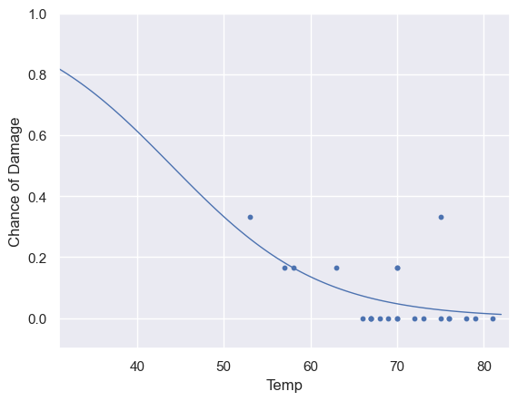

```python
plt.scatter(orings['temp'], orings['damage']/6, s = 10);
plt.xlim([31, orings['temp'].max() + 2]);
plt.ylim([-0.1,1]);
temps = np.linspace(31, orings['temp'].max()+1, 100).reshape(-1,1)
phat = logitmod.predict(np.hstack([temps, np.ones((len(temps),1))]))
plt.plot(temps, phat, linewidth = 1);
plt.xlabel("Temp");
plt.ylabel("Chance of Damage");
```

Despite the concerns raised by some engineers, it was ultimately decided to proceed with the launch. Tragically, just 73 seconds into the flight, the O-rings failed due to the cold temperatures, leading to the explosion of the shuttle.